# R Code Corresponding to the Book *The Handbook of Research Synthesis and Meta-Analysis* by Cooper et al. (2019)

## 11) Effect Sizes for Meta-Analysis

```r
# data for Figure 11.1

dat <- read.table(header=TRUE, text = "
study    md   n   var    se  pval
A     0.400  60 0.067 0.258 0.121
B     0.200 600 0.007 0.082 0.014
C     0.300 100 0.040 0.201 0.134
D     0.400 200 0.020 0.141 0.005
E     0.300 400 0.010 0.100 0.003
F    -0.200 200 0.020 0.141 0.157")
dat
```

```
##   study   md   n   var    se  pval
## 1     A  0.4  60 0.067 0.258 0.121
## 2     B  0.2 600 0.007 0.082 0.014
## 3     C  0.3 100 0.040 0.201 0.134
## 4     D  0.4 200 0.020 0.141 0.005
## 5     E  0.3 400 0.010 0.100 0.003
## 6     F -0.2 200 0.020 0.141 0.157
```

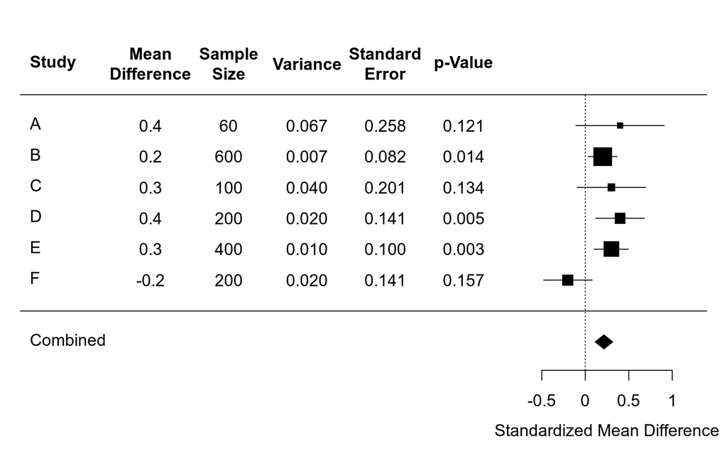

```r
# Figure 11.1

res <- rma(md, var, data=dat, method="EE", slab=study)

tmp <- dat[-1]
tmp$se  <- fmtx(tmp$se,  digits=3)
tmp$var <- fmtx(tmp$var, digits=3)

size <- sqrt(weights(res))
size <- 2.5 * size / max(size)

par(mar=c(5,4,2,2))

forest(res, xlim=c(-6.5,1.4), psize=size, header=TRUE, mlab="Combined",
       efac=c(0,1,2), annotate=FALSE, xlab="Standardized Mean Difference",
       ilab=tmp, ilab.xpos=c(-5.0, -4.1, -3.2, -2.3, -1.4))
text(-5.0, 8, "Mean\nDifference", font=2)
text(-4.1, 8, "Sample\nSize", font=2)
text(-3.2, 8, "Variance", font=2)
text(-2.3, 8, "Standard\nError", font=2)
text(-1.4, 8, "p-Value", font=2)
```

### Effect Sizes for a Comparison of Means

```r
# mean difference assuming sigma^2_1 = sigma^2_1

dat <- escalc("MD", m1i=103, m2i=100, sd1i=5.5, sd2i=4.5, n1i=50, n2i=50, vtype="HO")
summary(dat) # note: summary() so we can also see the standard error (sei)
```

```
##       yi     vi    sei     zi   pval  ci.lb  ci.ub
## 1 3.0000 1.0100 1.0050 2.9851 0.0028 1.0303 4.9697
```

```r
# mean difference not assuming sigma^2_1 = sigma^2_1

dat <- escalc("MD", m1i=103, m2i=100, sd1i=5.5, sd2i=4.5, n1i=50, n2i=50)
summary(dat)
```

```
##       yi     vi    sei     zi   pval  ci.lb  ci.ub
## 1 3.0000 1.0100 1.0050 2.9851 0.0028 1.0303 4.9697
```

```r
# note: since n1i=n2i in this example, the results are exactly the same
```

```r
# mean change

dat <- escalc("MC", m1i=105, m2i=100, sd1i=10, sd2i=10, ni=50, ri=0.5)
summary(dat)
```

```
##       yi     vi    sei     zi   pval  ci.lb  ci.ub
## 1 5.0000 2.0000 1.4142 3.5355 0.0004 2.2282 7.7718
```

```r
# standardized mean difference (Hedges' g)

dat <- escalc("SMD", m1i=103, m2i=100, sd1i=5.5, sd2i=4.5, n1i=50, n2i=50)
summary(dat)
```

```
##       yi     vi    sei     zi   pval  ci.lb  ci.ub
## 1 0.5924 0.0418 0.2043 2.8993 0.0037 0.1919 0.9929
```

```r
# note: by default, the sampling variance is computed in a slightly different way in the
# book compared to the metafor package; by using vtype="LS2", the exact same equation as
# given in the book is used; but the difference is usually negligible (the results below
# differ slightly from those given in the book due to intermittent rounding in the book)

dat <- escalc("SMD", m1i=103, m2i=100, sd1i=5.5, sd2i=4.5, n1i=50, n2i=50, vtype="LS2")
summary(dat)
```

```
##       yi     vi    sei     zi   pval  ci.lb  ci.ub
## 1 0.5924 0.0411 0.2028 2.9208 0.0035 0.1949 0.9900
```

```r
# standardized mean change (using raw score standardization)

dat <- escalc("SMCR", m1i=103, m2i=100, sd1i=5.5/sqrt(2*(1-0.7)), ni=50, ri=0.7)
summary(dat)
```

```
##       yi     vi    sei     zi   pval  ci.lb  ci.ub
## 1 0.4160 0.0137 0.1172 3.5502 0.0004 0.1863 0.6457
```

```r
# note: 5.5 is the SD of the change scores, which we can convert to the SD of
# the raw scores by dividing it by sqrt(2*(1-r)) (this assumes that the SD was
# the same at the pre- and post-test)
```

```r
# note: by default, the sampling variance is computed in a slightly different way in the
# book compared to the metafor package; by using vtype="LS2", the exact same equation as
# given in the book is used; but the difference is usually negligible (the results below
# differ slightly from those given in the book due to intermittent rounding in the book
# and also because the equation given in the book contains a mistake)

dat <- escalc("SMCR", m1i=103, m2i=100, sd1i=5.5/sqrt(2*(1-0.7)), ni=50, ri=0.7, vtype="LS2")
summary(dat)
```

```
##       yi     vi    sei     zi   pval  ci.lb  ci.ub
## 1 0.4160 0.0134 0.1156 3.5986 0.0003 0.1894 0.6426
```

```r
# standardized mean difference based on ANCOVA results

# note: not implemented in metafor, so we have to do the computations manually

Sw <- 5.5 / sqrt(1 - 0.7^2)
d  <- (103 - 100) / Sw
Vd <- (50 + 50) * (1 - 0.7^2) / (50 * 50) + d^2 / (2*(50 + 50 - 2 - 1))
J  <- metafor:::.cmicalc(50 + 50 - 2 - 1)
g  <- J * d
Vg <- J^2 * Vd
round(g,  digits=4)
```

```
## [1] 0.3865
```

```r
round(Vg, digits=4)
```

```
## [1] 0.0209
```

```r
round(sqrt(Vg), digits=4)
```

```
## [1] 0.1444
```

```r
# note: the results given in the book are not quite correct
```

### Correlations

```r
# r-to-z transformed correlation coefficient

dat <- escalc("ZCOR", ri=0.50, ni=100)
summary(dat)
```

```
##       yi     vi    sei     zi   pval  ci.lb  ci.ub
## 1 0.5493 0.0103 0.1015 5.4100 <.0001 0.3503 0.7483
```

```r
# back-transformation

c(transf.ztor(dat$yi))
```

```
## [1] 0.5
```

### Effect Sizes for Comparing Risks

```r
# risk difference

dat <- escalc("RD", ai=5, n1i=100, ci=10, n2i=100)
summary(dat)
```

```
##        yi     vi    sei      zi   pval   ci.lb  ci.ub
## 1 -0.0500 0.0014 0.0371 -1.3484 0.1775 -0.1227 0.0227
```

```r
# risk ratio (log transformed)

dat <- escalc("RR", ai=5, n1i=100, ci=10, n2i=100)
summary(dat)
```

```
##        yi     vi    sei      zi   pval   ci.lb  ci.ub
## 1 -0.6931 0.2800 0.5292 -1.3099 0.1902 -1.7303 0.3440
```

```r
# odds ratio (log transformed)

dat <- escalc("OR", ai=5, n1i=100, ci=10, n2i=100)
summary(dat)
```

```
##        yi     vi    sei      zi   pval   ci.lb  ci.ub
## 1 -0.7472 0.3216 0.5671 -1.3175 0.1877 -1.8588 0.3643
```

```r
# odds ratio (log transformed) for a case-control study

dat <- escalc("OR", ai=25, bi=20, ci=75, di=80)
summary(dat)
```

```
##       yi     vi    sei     zi   pval   ci.lb  ci.ub
## 1 0.2877 0.1158 0.3403 0.8453 0.3980 -0.3794 0.9547
```

## 12) Statistically Analyzing Effect Sizes: Equal- and Random-Effects Models

```r
# Table 12.1: Data for the Gender Differences in Conformity Example

dat <- read.table(header=TRUE, text = "
study group stdingrp nitems pmaleauth n d v
1  1 1  2 141 25  -0.330 0.029
2  1 2  2 119 25   0.070 0.034
3  2 1  2 191 50  -0.300 0.022
4  3 1 38 254 100  0.350 0.016
5  3 2 30  64 100  0.700 0.066
6  3 3 45  20 100  0.850 0.218
7  3 4 45  90 100  0.400 0.045
8  3 5 45  60 100  0.480 0.069
9  3 6  5  80 100  0.370 0.051
10 3 7  5 125 100 -0.060 0.032")

# note: including the 'percent male authors' variable from Table 12.3

dat
```

```
##    study group stdingrp nitems pmaleauth   n     d     v
## 1      1     1        1      2       141  25 -0.33 0.029
## 2      2     1        2      2       119  25  0.07 0.034
## 3      3     2        1      2       191  50 -0.30 0.022
## 4      4     3        1     38       254 100  0.35 0.016
## 5      5     3        2     30        64 100  0.70 0.066
## 6      6     3        3     45        20 100  0.85 0.218
## 7      7     3        4     45        90 100  0.40 0.045
## 8      8     3        5     45        60 100  0.48 0.069
## 9      9     3        6      5        80 100  0.37 0.051
## 10    10     3        7      5       125 100 -0.06 0.032
```

```r
# equal-effects model analysis

res <- rma(d, v, data=dat, method="EE")
print(res, digits=3)
```

```
## Equal-Effects Model (k = 10)
##
## I^2 (total heterogeneity / total variability):   71.68%
## H^2 (total variability / sampling variability):  3.53
##
## Test for Heterogeneity:
## Q(df = 9) = 31.776, p-val < .001
##
## Model Results:
##
## estimate     se   zval   pval  ci.lb  ci.ub
##    0.124  0.060  2.074  0.038  0.007  0.241  *
##
## ---
## Signif. codes:  0 '***' 0.001 '**' 0.01 '*' 0.05 '.' 0.1 ' ' 1
```

Note: The book uses the term ‘fixed-effects model’, but I will use the term ‘equal-effects model’ throughout this document. My reasons for using the latter term are explained [here](https://wviechtb.github.io/metafor/reference/misc-models.html).

```r
# random-effects model analysis

res <- rma(d, v, data=dat, method="DL")
print(res, digits=3)
```

```
## Random-Effects Model (k = 10; tau^2 estimator: DL)
##
## tau^2 (estimated amount of total heterogeneity): 0.094 (SE = 0.066)
## tau (square root of estimated tau^2 value):      0.307
## I^2 (total heterogeneity / total variability):   71.68%
## H^2 (total variability / sampling variability):  3.53
##
## Test for Heterogeneity:
## Q(df = 9) = 31.776, p-val < .001
##
## Model Results:
##
## estimate     se   zval   pval   ci.lb  ci.ub
##    0.189  0.118  1.594  0.111  -0.043  0.421
##
## ---
## Signif. codes:  0 '***' 0.001 '**' 0.01 '*' 0.05 '.' 0.1 ' ' 1
```

```r
# note: unfortunately, the estimate of tau^2 was not computed correctly in the
# book (c=242.1138, not 269.798) and hence all of the results given in the left
# column on page 251 are incorrect
```

```r
# fixed-effects ANOVA-type analysis

res <- rma(d, v, mods = ~ factor(group) - 1, data=dat, method="FE")
print(res, digits=3)
```

```
## Fixed-Effects with Moderators Model (k = 10)
##
## I^2 (residual heterogeneity / unaccounted variability): 36.85%
## H^2 (unaccounted variability / sampling variability):   1.58
##
## Test for Residual Heterogeneity:
## QE(df = 7) = 11.084, p-val = 0.135
##
## Test of Moderators (coefficients 1:3):
## QM(df = 3) = 24.992, p-val < .001
##
## Model Results:
##
##                 estimate     se    zval   pval   ci.lb   ci.ub
## factor(group)1    -0.146  0.125  -1.166  0.244  -0.391   0.099
## factor(group)2    -0.300  0.148  -2.023  0.043  -0.591  -0.009    *
## factor(group)3     0.339  0.077   4.421  <.001   0.189   0.490  ***
##
## ---
## Signif. codes:  0 '***' 0.001 '**' 0.01 '*' 0.05 '.' 0.1 ' ' 1
```

```r
# note: by removing the intercept, the three coefficients directly provide the
# estimated average effect for the three groups
```

```r
# weighted grand mean effect size

rma(coef(res), diag(vcov(res)), method="FE", digits=3)
```

```
## Fixed-Effects Model (k = 3)
##
## I^2 (total heterogeneity / total variability):   90.33%
## H^2 (total variability / sampling variability):  10.35
##
## Test for Heterogeneity:
## Q(df = 2) = 20.692, p-val < .001
##
## Model Results:
##
## estimate     se   zval   pval  ci.lb  ci.ub
##    0.124  0.060  2.074  0.038  0.007  0.241  *
##
## ---
## Signif. codes:  0 '***' 0.001 '**' 0.01 '*' 0.05 '.' 0.1 ' ' 1
```

```r
# partitioning of the Q-statistics

res <- rma(d, v, mods = ~ factor(group), data=dat, method="FE")
res
```

```
## Fixed-Effects with Moderators Model (k = 10)
##
## I^2 (residual heterogeneity / unaccounted variability): 36.85%
## H^2 (unaccounted variability / sampling variability):   1.58
## R^2 (amount of heterogeneity accounted for):            55.15%
##
## Test for Residual Heterogeneity:
## QE(df = 7) = 11.0843, p-val = 0.1350
##
## Test of Moderators (coefficients 2:3):
## QM(df = 2) = 20.6916, p-val < .0001
##
## Model Results:
##
##                 estimate      se     zval    pval    ci.lb   ci.ub
## intrcpt          -0.1459  0.1251  -1.1660  0.2436  -0.3911  0.0993
## factor(group)2   -0.1541  0.1940  -0.7943  0.4270  -0.5344  0.2262
## factor(group)3    0.4851  0.1468   3.3053  0.0009   0.1975  0.7728  ***
##
## ---
## Signif. codes:  0 '***' 0.001 '**' 0.01 '*' 0.05 '.' 0.1 ' ' 1
```

```r
# not removing the intercept, so the QM-statistic is equal to Q-between

round(res$QM, digits=3) # Q-between
```

```
## [1] 20.692
```

```r
round(res$QE, digits=3) # Q-within
```

```
## [1] 11.084
```

```r
# Q-within for each group

res1 <- rma(d, v, data=dat, method="FE", subset=group==1)
res2 <- rma(d, v, data=dat, method="FE", subset=group==2)
res3 <- rma(d, v, data=dat, method="FE", subset=group==3)

round(res1$QE, digits=3)
```

```
## [1] 2.54
```

```r
round(res2$QE, digits=3) # 0.0004 in the book, but must be exactly 0 since k=1
```

```
## [1] 0
```

```r
round(res3$QE, digits=3)
```

```
## [1] 8.545
```

```r
# these add up to Q-within above

round(res1$QE + res2$QE + res3$QE, digits=3)
```

```
## [1] 11.084
```

```r
# contrast between group 1 and 3

res <- rma(d, v, mods = ~ factor(group) - 1, data=dat, method="FE")
anova(res, X=c(-1,0,1), digits=3)
```

```
## Hypothesis:
## 1: -factor(group)1 + factor(group)3 = 0
##
## Results:
##    estimate    se  zval  pval
## 1:    0.485 0.147 3.305 <.001
##
## Test of Hypothesis:
## QM(df = 1) = 10.925, p-val < .001
```

```r
predict(res, newmods=c(-1,0,1), digits=3)
```

```
##   pred    se ci.lb ci.ub
##  0.485 0.147 0.197 0.773
```

```r
# note: the results given in the book are slightly off
```

```r
# mixed-effects model analysis

# distribution-free (method of moments) estimate of tau^2

res <- rma(d, v, mods = ~ factor(group), data=dat, method="DL")
round(res$tau2, digits=3)
```

```
## [1] 0.025
```

```r
# maximum likelihood estimate of tau^2

res <- rma(d, v, mods = ~ factor(group), data=dat, method="ML")
round(res$tau2, digits=3)
```

```
## [1] 0
```

```r
# restricted maximum likelihood estimate of tau^2

res <- rma(d, v, mods = ~ factor(group), data=dat, method="REML")
round(res$tau2, digits=3)
```

```
## [1] 0.027
```

```r
# note: the REML estimate is incorrectly claimed to be 0 in the book
```

```r
res <- rma(d, v, mods = ~ factor(group) - 1, data=dat, method="DL")
print(res, digits=3)
```

```
## Mixed-Effects Model (k = 10; tau^2 estimator: DL)
##
## tau^2 (estimated amount of residual heterogeneity):     0.025 (SE = 0.037)
## tau (square root of estimated tau^2 value):             0.157
## I^2 (residual heterogeneity / unaccounted variability): 36.85%
## H^2 (unaccounted variability / sampling variability):   1.58
##
## Test for Residual Heterogeneity:
## QE(df = 7) = 11.084, p-val = 0.135
##
## Test of Moderators (coefficients 1:3):
## QM(df = 3) = 15.062, p-val = 0.002
##
## Model Results:
##
##                 estimate     se    zval   pval   ci.lb  ci.ub
## factor(group)1    -0.139  0.168  -0.829  0.407  -0.467  0.190
## factor(group)2    -0.300  0.216  -1.387  0.165  -0.724  0.124
## factor(group)3     0.361  0.102   3.528  <.001   0.161  0.562  ***
##
## ---
## Signif. codes:  0 '***' 0.001 '**' 0.01 '*' 0.05 '.' 0.1 ' ' 1
```

```r
# note: by removing the intercept, the three coefficients directly provide the
# estimated average effect for the three groups

# weighted grand mean effect size

rma(coef(res), diag(vcov(res)), method="FE", digits=3)
```

```
## Fixed-Effects Model (k = 3)
##
## I^2 (total heterogeneity / total variability):   82.69%
## H^2 (total variability / sampling variability):  5.78
##
## Test for Heterogeneity:
## Q(df = 2) = 11.557, p-val = 0.003
##
## Model Results:
##
## estimate     se   zval   pval   ci.lb  ci.ub
##    0.152  0.081  1.872  0.061  -0.007  0.310  .
##
## ---
## Signif. codes:  0 '***' 0.001 '**' 0.01 '*' 0.05 '.' 0.1 ' ' 1
```

```r
# contrast between group 1 and 3

anova(res, X=c(-1,0,1), digits=3)
```

```
## Hypothesis:
## 1: -factor(group)1 + factor(group)3 = 0
##
## Results:
##    estimate    se  zval  pval
## 1:    0.500 0.196 2.547 0.011
##
## Test of Hypothesis:
## QM(df = 1) = 6.485, p-val = 0.011
```

```r
predict(res, newmods=c(-1,0,1), digits=3)
```

```
##   pred    se ci.lb ci.ub pi.lb pi.ub
##  0.500 0.196 0.115 0.885 0.007 0.993
```

```r
# meta-regression model

res <- rma(d, v, mods = ~ I(log(nitems)), data=dat, method="FE")
print(res, digits=3)
```

```
## Fixed-Effects with Moderators Model (k = 10)
##
## I^2 (residual heterogeneity / unaccounted variability): 7.66%
## H^2 (unaccounted variability / sampling variability):   1.08
## R^2 (amount of heterogeneity accounted for):            69.33%
##
## Test for Residual Heterogeneity:
## QE(df = 8) = 8.664, p-val = 0.371
##
## Test of Moderators (coefficient 2):
## QM(df = 1) = 23.112, p-val < .001
##
## Model Results:
##
##                 estimate     se    zval   pval   ci.lb   ci.ub
## intrcpt           -0.323  0.111  -2.922  0.003  -0.540  -0.106   **
## I(log(nitems))     0.210  0.044   4.808  <.001   0.125   0.296  ***
##
## ---
## Signif. codes:  0 '***' 0.001 '**' 0.01 '*' 0.05 '.' 0.1 ' ' 1
```

```r
# note: when doing transformations on predictors (such as taking the log) in
# the model formula, then we need to wrap this inside the I() function
```

```r
# mixed-effects meta-regression model

# distribution-free (method of moments) estimate of tau^2

res <- rma(d, v, mods = ~ I(log(nitems)), data=dat, method="DL")
round(res$tau2, digits=3)
```

```
## [1] 0.003
```

```r
# maximum likelihood estimate of tau^2

res <- rma(d, v, mods = ~ I(log(nitems)), data=dat, method="ML")
round(res$tau2, digits=3)
```

```
## [1] 0
```

```r
# restricted maximum likelihood estimate of tau^2

res <- rma(d, v, mods = ~ I(log(nitems)), data=dat, method="REML")
round(res$tau2, digits=3)
```

```
## [1] 0.004
```

```r
# note: the REML estimate is incorrectly claimed to be 0 in the book
```

```r
# continuing with the distribution-free (method of moments) estimate of tau^2

res <- rma(d, v, mods = ~ I(log(nitems)), data=dat, method="DL")
print(res, digits=3)
```

```
## Mixed-Effects Model (k = 10; tau^2 estimator: DL)
##
## tau^2 (estimated amount of residual heterogeneity):     0.003 (SE = 0.021)
## tau (square root of estimated tau^2 value):             0.057
## I^2 (residual heterogeneity / unaccounted variability): 7.66%
## H^2 (unaccounted variability / sampling variability):   1.08
## R^2 (amount of heterogeneity accounted for):            96.53%
##
## Test for Residual Heterogeneity:
## QE(df = 8) = 8.664, p-val = 0.371
##
## Test of Moderators (coefficient 2):
## QM(df = 1) = 20.821, p-val < .001
##
## Model Results:
##
##                 estimate     se    zval   pval   ci.lb   ci.ub
## intrcpt           -0.321  0.117  -2.744  0.006  -0.550  -0.092   **
## I(log(nitems))     0.212  0.046   4.563  <.001   0.121   0.303  ***
##
## ---
## Signif. codes:  0 '***' 0.001 '**' 0.01 '*' 0.05 '.' 0.1 ' ' 1
```

```r
# robust variance estimation

robust(res, cluster=study, digits=3)
```

```
## Mixed-Effects Model (k = 10; tau^2 estimator: DL)
##
## tau^2 (estimated amount of residual heterogeneity):     0.003 (SE = 0.021)
## tau (square root of estimated tau^2 value):             0.057
## I^2 (residual heterogeneity / unaccounted variability): 7.66%
## H^2 (unaccounted variability / sampling variability):   1.08
## R^2 (amount of heterogeneity accounted for):            96.53%
##
## Test for Residual Heterogeneity:
## QE(df = 8) = 8.664, p-val = 0.371
##
## Number of estimates:   10
## Number of clusters:    10
## Estimates per cluster: 1
##
## Test of Moderators (coefficient 2):¹
## F(df1 = 1, df2 = 8) = 25.315, p-val = 0.001
##
## Model Results:
##
##                 estimate     se¹    tval¹  df¹   pval¹   ci.lb¹   ci.ub¹
## intrcpt           -0.321  0.124   -2.586    8   0.032   -0.607   -0.035    *
## I(log(nitems))     0.212  0.042    5.031    8   0.001    0.115    0.309   **
##
## ---
## Signif. codes:  0 '***' 0.001 '**' 0.01 '*' 0.05 '.' 0.1 ' ' 1
##
## 1) results based on cluster-robust inference (var-cov estimator: CR1,
##    approx t/F-tests and confidence intervals, df: residual method)
```

```r
# note: the test statistic for log(nitems) is somewhat off in the book
```

## 13) Stochastically Dependent Effect Sizes

```r
# Table 13.1

dat <- dat.kalaian1996[c(1:8,17:29,9:16,30:31),c(2,4:5,7,6,8)]
dat$study <- rep(1:26, times=rle(dat$study)$lengths)
names(dat) <- c("study", "nt", "nc", "d", "outcome", "v")
dat
```

```
##    study  nt  nc     d outcome      v
## 1      1  28  22  0.22  verbal 0.0817
## 2      2  39  40  0.09  verbal 0.0507
## 3      3  22  17  0.14  verbal 0.1045
## 4      4  48  43  0.14  verbal 0.0442
## 5      5  25  74 -0.01  verbal 0.0535
## 6      6  37  35  0.14  verbal 0.0557
## 7      7  24  70  0.18  verbal 0.0561
## 8      8  16  19  0.01  verbal 0.1151
## 17     9  43  37  0.01  verbal 0.0503
## 18    10  19  13  0.67  verbal 0.1366
## 19    11  16  11 -0.38  verbal 0.1561
## 20    12  20  12 -0.24  verbal 0.1342
## 21    13  39  28  0.29  verbal 0.0620
## 22    14  38  25  0.26    math 0.0669
```

[output cut: 17 more lines]

```r
# note: this is a subset of the studies in dat.kalaian1996; instead of using
# dummy variable 'x' (where x=0 for the verbal and x=1 for the math subtest),
# we use the 'outcome' variable that has more descriptive labels
```

```r
# construct variance-covariance matrices assuming rho = 0.7

V <- vcalc(v, cluster=study, type=outcome, rho=0.7, data=dat)

# var-cov matrix for studies 22 to 26

blsplit(V, cluster=dat$study, round, 4)[22:26]
```

```
## $`22`
##        [,1]   [,2]
## [1,] 0.0147 0.0103
## [2,] 0.0103 0.0147
##
## $`23`
##        [,1]   [,2]
## [1,] 0.0218 0.0152
## [2,] 0.0152 0.0216
##
## $`24`
##        [,1]   [,2]
## [1,] 0.0221 0.0154
## [2,] 0.0154 0.0219
##
## $`25`
##        [,1]   [,2]
## [1,] 0.1484 0.1039
## [2,] 0.1039 0.1484
##
## $`26`
##        [,1]   [,2]
## [1,] 0.1216 0.0862
## [2,] 0.0862 0.1248
```

```r
# multivariate model with (correlated) random effects for both outcomes

res <- rma.mv(d, V, mods = ~ outcome - 1,
              random = ~ outcome | study, struct="UN", data=dat)
print(res, digits=3)
```

```
## Multivariate Meta-Analysis Model (k = 31; method: REML)
##
## Variance Components:
##
## outer factor: study   (nlvls = 26)
## inner factor: outcome (nlvls = 2)
##
##            estim   sqrt  k.lvl  fixed   level
## tau^2.1    0.001  0.025     13     no    math
## tau^2.2    0.000  0.021     18     no  verbal
##
##         rho.math  rho.vrbl    math  vrbl
## math           1                 -     5
## verbal    -1.000         1      no     -
##
## Test for Residual Heterogeneity:
## QE(df = 29) = 19.902, p-val = 0.896
##
## Test of Moderators (coefficients 1:2):
## QM(df = 2) = 9.417, p-val = 0.009
##
## Model Results:
##
##                estimate     se   zval   pval   ci.lb  ci.ub
## outcomemath       0.089  0.059  1.511  0.131  -0.026  0.204
## outcomeverbal     0.158  0.051  3.067  0.002   0.057  0.258  **
##
## ---
## Signif. codes:  0 '***' 0.001 '**' 0.01 '*' 0.05 '.' 0.1 ' ' 1
```

```r
# note: by removing the intercept, the two coefficients directly provide the
# estimated average effect for the two outcomes

# note: both variance components are very close to 0; as in the book, we
# proceed with a model where both variances are constrained to be equal to 0
```

```r
# multivariate fixed-effects model

res <- rma.mv(d, V, mods = ~ outcome - 1, data=dat)
print(res, digits=3)
```

```
## Multivariate Meta-Analysis Model (k = 31; method: REML)
##
## Variance Components: none
##
## Test for Residual Heterogeneity:
## QE(df = 29) = 19.902, p-val = 0.896
##
## Test of Moderators (coefficients 1:2):
## QM(df = 2) = 9.813, p-val = 0.007
##
## Model Results:
##
##                estimate     se   zval   pval   ci.lb  ci.ub
## outcomemath       0.086  0.057  1.507  0.132  -0.026  0.198
## outcomeverbal     0.159  0.051  3.131  0.002   0.059  0.258  **
##
## ---
## Signif. codes:  0 '***' 0.001 '**' 0.01 '*' 0.05 '.' 0.1 ' ' 1
```

```r
# fit model with varying values of rho

rhos <- c(0, 0.5, 0.6, 0.7, 0.8)
res <- list()
for (i in 1:length(rhos)) {
   V <- vcalc(v, cluster=study, type=outcome, rho=rhos[i], data=dat)
   res[[i]] <- rma.mv(d, V, mods = ~ outcome - 1, data=dat)
}

# Table 13.2

tab <- data.frame(rho  = rhos,
                  b1   = sapply(res, function(x) coef(x)[1]),
                  s1   = sapply(res, function(x) x$se[1]),
                  lcl1 = sapply(res, function(x) x$ci.lb[1]),
                  ucl1 = sapply(res, function(x) x$ci.ub[1]),
                  z1   = sapply(res, function(x) x$zval[1]),
                  b2   = sapply(res, function(x) coef(x)[2]),
                  s2   = sapply(res, function(x) x$se[2]),
                  lcl2 = sapply(res, function(x) x$ci.lb[2]),
                  ucl2 = sapply(res, function(x) x$ci.ub[2]),
                  z2   = sapply(res, function(x) x$zval[2]))
dfround(tab, digits=c(1,2,3,2,2,2,2,3,2,2,2))
```

```
##   rho   b1    s1  lcl1 ucl1   z1   b2    s2 lcl2 ucl2   z2
## 1 0.0 0.11 0.064 -0.01 0.24 1.77 0.15 0.053 0.05 0.26 2.93
## 2 0.5 0.09 0.060 -0.02 0.21 1.56 0.16 0.052 0.06 0.26 3.03
## 3 0.6 0.09 0.059 -0.03 0.21 1.53 0.16 0.051 0.06 0.26 3.08
## 4 0.7 0.09 0.057 -0.03 0.20 1.51 0.16 0.051 0.06 0.26 3.13
## 5 0.8 0.08 0.055 -0.03 0.19 1.49 0.16 0.050 0.06 0.26 3.20
```

```r
# note: there are some printing errors in the table in the book;
# also the values given in the Z_2 column in the book are quite off
```

```r
# robust variance estimation

V <- vcalc(v, cluster=study, type=outcome, rho=0.7, data=dat)
res <- rma.mv(d, V, mods = ~ outcome - 1, data=dat)
robust(res, cluster=study)
```

```
## Multivariate Meta-Analysis Model (k = 31; method: REML)
##
## Variance Components: none
##
## Test for Residual Heterogeneity:
## QE(df = 29) = 19.9016, p-val = 0.8960
##
## Number of estimates:   31
## Number of clusters:    26
## Estimates per cluster: 1-2 (mean: 1.19, median: 1)
##
## Test of Moderators (coefficients 1:2):¹
## F(df1 = 2, df2 = 24) = 12.1231, p-val = 0.0002
##
## Model Results:
##
##                estimate      se¹    tval¹  df¹    pval¹   ci.lb¹   ci.ub¹
## outcomemath      0.0861  0.0383   2.2490   24   0.0340   0.0071   0.1651     *
## outcomeverbal    0.1589  0.0362   4.3950   24   0.0002   0.0843   0.2336   ***
##
## ---
## Signif. codes:  0 '***' 0.001 '**' 0.01 '*' 0.05 '.' 0.1 ' ' 1
##
## 1) results based on cluster-robust inference (var-cov estimator: CR1,
##    approx t/F-tests and confidence intervals, df: residual method)
```

```r
# note: this is not the exact same approach that is described in the book; it
# uses a different weighting scheme and uses k-p for the degrees of freedom
# for the t-statistics; we can make use of the 'effective degrees of freedom'
# method described in the book with the 'clubSandwich' package
```

```r
# install the 'clubSandwich' package (if it is not already installed) and load it

if (!require(clubSandwich))
   install.packages("clubSandwich")
```

```r
robust(res, cluster=study, clubSandwich=TRUE)
```

```
## Multivariate Meta-Analysis Model (k = 31; method: REML)
##
## Variance Components: none
##
## Test for Residual Heterogeneity:
## QE(df = 29) = 19.9016, p-val = 0.8960
##
## Number of estimates:   31
## Number of clusters:    26
## Estimates per cluster: 1-2 (mean: 1.19, median: 1)
##
## Test of Moderators (coefficients 1:2):¹
## F(df1 = 2, df2 = 5.28) = 10.5212, p-val = 0.0144
##
## Model Results:
##
##                estimate      se¹    tval¹     df¹    pval¹    ci.lb¹   ci.ub¹
## outcomemath      0.0861  0.0395   2.1819    6.67   0.0674   -0.0082   0.1803    .
## outcomeverbal    0.1589  0.0370   4.2915   11.03   0.0013    0.0774   0.2404   **
##
## ---
## Signif. codes:  0 '***' 0.001 '**' 0.01 '*' 0.05 '.' 0.1 ' ' 1
##
## 1) results based on cluster-robust inference (var-cov estimator: CR2,
##    approx t/F-tests and confidence intervals, df: Satterthwaite approx)
```

```r
# note: but these are still not the same results as given in the book because
# of the different weighting scheme; we can get the same results as given in
# the book with the 'robumeta' package
```

```r
# install the 'robumeta' package (if it is not already installed) and load it

if (!require(robumeta)) {
   install.packages("robumeta")
   library(robumeta)
}
```

```r
robu(d ~ outcome - 1, data=dat, studynum=study, var.eff.size=v, rho=0.7, small=TRUE)
```

```
## RVE: Correlated Effects Model with Small-Sample Corrections
##
## Model: d ~ outcome - 1
##
## Number of studies = 26
## Number of outcomes = 31 (min = 1 , mean = 1.19 , median = 1 , max = 2 )
## Rho = 0.7
## I.sq = 0
## Tau.sq = 0
##
##                 Estimate StdErr t-value   dfs P(|t|>)  95% CI.L 95% CI.U Sig
## 1   outcomemath    0.114 0.0489    2.32  7.69 0.05018 -0.000115    0.227   *
## 2 outcomeverbal    0.140 0.0338    4.12 13.09 0.00119  0.066450    0.213 ***
## ---
## Signif. codes: < .01 *** < .05 ** < .10 *
## ---
## Note: If df < 4, do not trust the results
```

```r
# note: the value of rho actually has no influence on these results
```

```r
# reproduce robumeta results using metafor and clubSandwich

vcalcfun <- function(v, tau2)
   diag((tau2 + mean(v)) * length(v), nrow=length(v), ncol=length(v))

V <- lapply(split(dat$v, dat$study), vcalcfun, tau2=0)
res <- rma.mv(d, V, mods = ~ outcome - 1, data=dat)
robust(res, cluster=study, clubSandwich=TRUE)
```

```
## Multivariate Meta-Analysis Model (k = 31; method: REML)
##
## Variance Components: none
##
## Test for Residual Heterogeneity:
## QE(df = 29) = 14.6868, p-val = 0.9873
##
## Number of estimates:   31
## Number of clusters:    26
## Estimates per cluster: 1-2 (mean: 1.19, median: 1)
##
## Test of Moderators (coefficients 1:2):¹
## F(df1 = 2, df2 = 10.54) = 11.0146, p-val = 0.0026
##
## Model Results:
##
##                estimate      se¹    tval¹     df¹    pval¹    ci.lb¹   ci.ub¹
## outcomemath      0.1135  0.0489   2.3198    7.69   0.0502   -0.0001   0.2272    .
## outcomeverbal    0.1395  0.0338   4.1220   13.09   0.0012    0.0664   0.2126   **
##
## ---
## Signif. codes:  0 '***' 0.001 '**' 0.01 '*' 0.05 '.' 0.1 ' ' 1
##
## 1) results based on cluster-robust inference (var-cov estimator: CR2,
##    approx t/F-tests and confidence intervals, df: Satterthwaite approx)
```

```r
# construct dataset with synthetic effects

agg <- aggregate(dat, by=list(dat$study), function(x) {
   if (is.character(x))
      paste(unique(x), collapse="/")
   else
      mean(x)
   })
agg$Group.1 <- agg$x <- NULL
agg
```

```
##    study  nt  nc      d     outcome      v
## 1      1  28  22  0.220      verbal 0.0817
## 2      2  39  40  0.090      verbal 0.0507
## 3      3  22  17  0.140      verbal 0.1045
## 4      4  48  43  0.140      verbal 0.0442
## 5      5  25  74 -0.010      verbal 0.0535
## 6      6  37  35  0.140      verbal 0.0557
## 7      7  24  70  0.180      verbal 0.0561
## 8      8  16  19  0.010      verbal 0.1151
## 9      9  43  37  0.010      verbal 0.0503
## 10    10  19  13  0.670      verbal 0.1366
## 11    11  16  11 -0.380      verbal 0.1561
## 12    12  20  12 -0.240      verbal 0.1342
## 13    13  39  28  0.290      verbal 0.0620
## 14    14  38  25  0.260        math 0.0669
## 15    15  18  13 -0.410        math 0.1352
## 16    16  19  13  0.080        math 0.1297
## 17    17  37  22  0.300        math 0.0732
## 18    18  19  11 -0.530        math 0.1482
## 19    19  17  13  0.130        math 0.1360
## 20    20  20  12  0.260        math 0.1344
## 21    21  20  13  0.470        math 0.1303
## 22    22 145 129  0.125 verbal/math 0.0147
## 23    23  72 129  0.155 verbal/math 0.0217
## 24    24  71 129  0.200 verbal/math 0.0220
## 25    25  13  14  0.035 verbal/math 0.1484
## 26    26  16  17  0.305 verbal/math 0.1232
```

```r
# fit standard random-effects model to the dataset with synthetic effects

res <- rma(d, v, data=agg, method="DL")
print(res, digits=3)
```

```
## Random-Effects Model (k = 26; tau^2 estimator: DL)
##
## tau^2 (estimated amount of total heterogeneity): 0 (SE = 0.018)
## tau (square root of estimated tau^2 value):      0
## I^2 (total heterogeneity / total variability):   0.00%
## H^2 (total variability / sampling variability):  1.00
##
## Test for Heterogeneity:
## Q(df = 25) = 13.530, p-val = 0.969
##
## Model Results:
##
## estimate     se   zval   pval  ci.lb  ci.ub
##    0.130  0.048  2.699  0.007  0.036  0.224  **
##
## ---
## Signif. codes:  0 '***' 0.001 '**' 0.01 '*' 0.05 '.' 0.1 ' ' 1
```

## 14) Bayesian Meta-Analysis

For these analyses, we could do most of what is described in the chapter using the excellent brms package. However, to fully reproduce all of the analyses conducted, we either need to use [WinBUGS](https://www.mrc-bsu.cam.ac.uk/software/bugs/the-bugs-project-winbugs/) (as was done by the chapter authors) or we can use [JAGS](http://mcmc-jags.sourceforge.net/) (which has the advantage that it runs not just under Windows, but also macOS / Mac OS X and Linux). Here, we will make use of the latter, which we can interact with directly from R via the rjags package. Note that JAGS needs to be installed separately (follow the link above for installation instructions).

```r
# install the 'rjags' package (if it is not already installed) and load it

if (!require(rjags)) {
   install.packages("rjags")
   library(rjags)
}
```

```r
# Table 14.1: Respiratory Tract Infections Data

dat <- dat.damico2009[c(1:8,16,9:15),-8]
dat$conceal <- 1 - dat$conceal
rownames(dat) <- 1:nrow(dat)
dat <- escalc(measure="OR", ai=xt, n1i=nt, ci=xc, n2i=nc, data=dat, digits=2)
dat
```

```
##             study year xt  nt  xc  nc conceal    yi   vi
## 1      Abele-Horn 1997 13  58  23  30       1 -2.43 0.29
## 2          Aerdts 1991  1  28  29  60       0 -3.23 1.10
## 3           Blair 1991 12 161  38 170       0 -1.27 0.12
## 4          Boland 1991 14  32  17  32       1 -0.38 0.25
## 5       Cockerill 1992  4  75  12  75       1 -1.22 0.36
## 6           Finch 1991  4  20   7  24       0 -0.50 0.51
## 7          Jacobs 1992  0  45   4  46       1 -2.27 2.27
## 8          Kerver 1988  5  49  31  47       1 -2.84 0.32
## 9         Krueger 2002 91 265 149 262       0 -0.92 0.03
## 10        Palomar 1997 10  50  25  49       1 -1.43 0.21
## 11          Rocha 1992  7  47  25  54       1 -1.59 0.24
## 12 Sanchez-Garcia 1992 32 131  60 140       0 -0.84 0.07
## 13    Stoutenbeek 2007 62 201 100 200       0 -0.81 0.04
## 14         Ulrich 1989  7  55  26  57       0 -1.75 0.23
## 15       Verwaest 1997 22 193  40 185       0 -0.76 0.08
## 16         Winter 1992  3  91  17  92       0 -1.89 0.42
```

```r
# note: including 'conceal' variable (coded 0 = allocation concealment
# adequate, 1 = allocation concealment inadequate)
```

```r
# Bayesian equal-effects model

k <- length(dat$yi)

jags.data <- list(yi=dat$yi, vi=dat$vi, k=k)

fe.model <- "model {
   for (i in 1:k) {
      yi[i] ~ dnorm(theta, 1/vi[i])
   }
   theta ~ dnorm(0, 0.0001)
}"

inits <- list(theta=0, .RNG.name="base::Mersenne-Twister")
inits <- list(inits, inits, inits)
inits[[1]]$.RNG.seed <- 12341
inits[[2]]$.RNG.seed <- 12342
inits[[3]]$.RNG.seed <- 12343

# note: usually 'inits <- list(theta=0)' would have been sufficient; however,
# for full reproducibility, I am setting the random number generator and
# the seed for each chain (the same will be done below for other models)

model <- jags.model(textConnection(fe.model), inits=inits, data=jags.data, n.chains=3, quiet=TRUE)
update(model, n.iter=10000, progress.bar="none")
bma.ee <- coda.samples(model, variable.names=c("theta"), n.iter=100000, progress.bar="none")
dic.ee <- dic.samples(model, n.iter=100000, type="pD", progress.bar="none")
bma.ee <- summary(bma.ee)$quantiles[c(3,1,5)]
bma.ee <- rbind(theta=bma.ee, exp.theta = exp(bma.ee))
round(bma.ee, digits=2)
```

```
##             50%  2.5% 97.5%
## theta     -1.09 -1.27 -0.91
## exp.theta  0.34  0.28  0.40
```

```r
# compare with results from a non-Bayesian analysis

res.ee <- rma(yi, vi, data=dat, method="EE", digits=2)
predict(res.ee, transf=exp)
```

```
##  pred ci.lb ci.ub
##  0.34  0.28  0.40
```

```r
# Bayesian random-effects model with uniform(0,2) prior for tau

re.model <- "model {
   for (i in 1:k) {
      yi[i] ~ dnorm(theta[i], 1/vi[i])
      theta[i] ~ dnorm(mu, 1/tau2)
   }
   mu ~ dnorm(0, 0.0001)
   tau ~ dunif(0, 2)
   tau2 <- tau^2
   theta.2 <- theta[2]
   theta.3 <- theta[3]
   theta.new ~ dnorm(mu, 1/tau2)
}"

inits <- list(theta=rep(0,k), theta.new=0, mu=0, tau=1, .RNG.name="base::Mersenne-Twister")
inits <- list(inits, inits, inits)
inits[[1]]$.RNG.seed <- 12341
inits[[2]]$.RNG.seed <- 12342
inits[[3]]$.RNG.seed <- 12343

model <- jags.model(textConnection(re.model), inits=inits, data=jags.data, n.chains=3, quiet=TRUE)
update(model, n.iter=10000, progress.bar="none")
bma.re <- coda.samples(model, variable.names=c("mu","tau2","theta.2","theta.3","theta.new"),
                       n.iter=100000, progress.bar="none")
dic.re <- dic.samples(model, n.iter=100000, type="pD", progress.bar="none")
bma.re <- summary(bma.re)$quantiles[,c(3,1,5)]
bma.re <- rbind(mu=bma.re[1,], exp.mu=exp(bma.re[1,]), tau2=bma.re[2,],
                bma.re[3:5,], exp.theta.new=exp(bma.re[5,]))
round(bma.re[1:3,], digits=2)
```

```
##          50%  2.5% 97.5%
## mu     -1.29 -1.73 -0.94
## exp.mu  0.28  0.18  0.39
## tau2    0.27  0.01  1.09
```

```r
# compare with results from a non-Bayesian analysis

res.re <- rma(yi, vi, data=dat, method="DL", digits=2)
pred.re <- predict(res.re, transf=exp)
pred.re
```

```
##  pred ci.lb ci.ub pi.lb pi.ub
##  0.28  0.20  0.38  0.12  0.67
```

```r
conf.re <- confint(res.re)
round(conf.re$random["tau^2",], digits=2)
```

```
## estimate    ci.lb    ci.ub
##     0.18     0.04     1.20
```

```r
# Bayesian random-effects model with half-normal(0,0.5^2) prior for tau

re.model <- "model {
   for (i in 1:k) {
      yi[i] ~ dnorm(theta[i], 1/vi[i])
      theta[i] ~ dnorm(mu, 1/tau2)
   }
   mu ~ dnorm(0, 0.0001)
   tau ~ dnorm(0, 1/0.5^2) T(0,)
   tau2 <- tau^2
}"

inits <- list(theta=rep(0,k), mu=0, tau=1, .RNG.name="base::Mersenne-Twister")
inits <- list(inits, inits, inits)
inits[[1]]$.RNG.seed <- 12341
inits[[2]]$.RNG.seed <- 12342
inits[[3]]$.RNG.seed <- 12343

model <- jags.model(textConnection(re.model), inits=inits, data=jags.data, n.chains=3, quiet=TRUE)
update(model, n.iter=10000, progress.bar="none")
bma.hn <- coda.samples(model, variable.names=c("mu","tau2"), n.iter=100000, progress.bar="none")
bma.hn <- summary(bma.hn)$quantiles[,c(3,1,5)]
bma.hn <- rbind(mu=bma.hn[1,], exp.mu=exp(bma.hn[1,]), tau2=bma.hn[2,])
```

```r
# Bayesian random-effects model with gamma(0.001,0.001) prior for 1/tau^2

re.model <- "model {
   for (i in 1:k) {
      yi[i] ~ dnorm(theta[i], 1/vi[i])
      theta[i] ~ dnorm(mu, prec)
   }
   mu ~ dnorm(0, 0.0001)
   prec ~ dgamma(0.001, 0.001)
   tau2 <- 1/prec
}"

inits <- list(theta=rep(0,k), mu=0, prec=1, .RNG.name="base::Mersenne-Twister")
inits <- list(inits, inits, inits)
inits[[1]]$.RNG.seed <- 12341
inits[[2]]$.RNG.seed <- 12342
inits[[3]]$.RNG.seed <- 12343

model <- jags.model(textConnection(re.model), inits=inits, data=jags.data, n.chains=3, quiet=TRUE)
update(model, n.iter=10000, progress.bar="none")
bma.ig <- coda.samples(model, variable.names=c("mu","tau2"), n.iter=100000, progress.bar="none")
bma.ig <- summary(bma.ig)$quantiles[,c(3,1,5)]
bma.ig <- rbind(mu=bma.ig[1,], exp.mu=exp(bma.ig[1,]), tau2=bma.ig[2,])
```

```r
# Table 14.2

tab <- rbind(
   c(or = pred.re$pred, ci.lb = pred.re$ci.lb, ci.ub = pred.re$ci.ub,
     tau2 = conf.re$random[1,1], ci.lb = conf.re$random[1,2], ci.ub = conf.re$random[1,3]),
   c(bma.re[2,], bma.re[3,]), c(bma.hn[2,], bma.hn[3,]), c(bma.ig[2,], bma.ig[3,]))
rownames(tab) <- c("Frequentist RE model",
                   "Bayesian RE model, uniform(0,2) prior for tau",
                   "Bayesian RE model, half-normal(0,0.5^2) prior for tau",
                   "Bayesian RE model, gamma(0.001,0.001) prior for 1/tau^2")
round(tab, digits=2)
```

```
##                                                           or ci.lb ci.ub tau2 ci.lb ci.ub
## Frequentist RE model                                    0.28  0.20  0.38 0.18  0.04  1.20
## Bayesian RE model, uniform(0,2) prior for tau           0.28  0.18  0.39 0.27  0.01  1.09
## Bayesian RE model, half-normal(0,0.5^2) prior for tau   0.28  0.19  0.39 0.19  0.01  0.70
## Bayesian RE model, gamma(0.001,0.001) prior for 1/tau^2 0.29  0.19  0.39 0.16  0.00  0.82
```

```r
# Bayesian random-effects meta-regression model with uniform(0,2) prior for tau

jags.data <- list(yi=dat$yi, vi=dat$vi, xi=dat$conceal, k=k)

me.model <- "model {
   for (i in 1:k) {
      yi[i] ~ dnorm(theta[i], 1/vi[i])
      theta[i] ~ dnorm(beta0 + beta1 * xi[i], 1/tau2)
   }
   beta0 ~ dnorm(0, 0.0001)
   beta1 ~ dnorm(0, 0.0001)
   tau ~ dunif(0, 2)
   tau2 <- tau^2
   betasum <- beta0 + beta1
}"

inits <- list(theta=rep(0,k), beta0=0, beta1=1, tau=1, .RNG.name="base::Mersenne-Twister")
inits <- list(inits, inits, inits)
inits[[1]]$.RNG.seed <- 12341
inits[[2]]$.RNG.seed <- 12342
inits[[3]]$.RNG.seed <- 12343

model <- jags.model(textConnection(me.model), inits=inits, data=jags.data, n.chains=3, quiet=TRUE)
update(model, n.iter=10000, progress.bar="none")
bma.me <- coda.samples(model, variable.names=c("beta0","beta1","tau2","betasum"),
                       n.iter=100000, progress.bar="none")
dic.me <- dic.samples(model, n.iter=100000, type="pD", progress.bar="none")
bma.me <- summary(bma.me)$quantiles[,c(3,1,5)]
bma.me <- rbind(bma.me[c(1,2,4),], exp.beta0=exp(bma.me[1,]), exp.betasum=exp(bma.me[3,]))
round(bma.me, digits=2)
```

```
##               50%  2.5% 97.5%
## beta0       -1.05 -1.55 -0.71
## beta1       -0.58 -1.22  0.16
## tau2         0.12  0.00  0.87
## exp.beta0    0.35  0.21  0.49
## exp.betasum  0.19  0.11  0.33
```

```r
# compare with results from a non-Bayesian analysis

res.me <- rma(yi, vi, mods = ~ conceal, data=dat, method="DL", digits=2)
predict(res.me, newmods=c(0,1), transf=exp)
```

```
##   pred ci.lb ci.ub pi.lb pi.ub
## 1 0.34  0.25  0.48  0.16  0.74
## 2 0.20  0.12  0.32  0.08  0.45
```

```r
round(confint(res.me)$random["tau^2",], digits=2)
```

```
## estimate    ci.lb    ci.ub
##     0.12     0.00     1.23
```

```r
# Table 14.3

tab <- rbind(c(sum(dic.ee$deviance), sum(dic.ee[[2]]), sum(dic.ee$deviance) + sum(dic.ee[[2]])),
             c(sum(dic.re$deviance), sum(dic.re[[2]]), sum(dic.re$deviance) + sum(dic.re[[2]])),
             c(sum(dic.me$deviance), sum(dic.me[[2]]), sum(dic.me$deviance) + sum(dic.me[[2]])))
colnames(tab) <- c("mean(D)", "p_D", "DIC")
rownames(tab) <- c("Equal-effect meta-analysis",
                   "Random-effects meta-analysis",
                   "Random-effects meta-regression")
round(tab, digits=1)
```

```
##                                mean(D) p_D  DIC
## Equal-effect meta-analysis        40.3 1.0 41.3
## Random-effects meta-analysis      24.4 9.7 34.1
## Random-effects meta-regression    26.5 8.3 34.7
```

```r
# shrunken estimates for Aerdts (1991) and Blair (1991)

round(bma.re[4:5,], digits=2)
```

```
##           50%  2.5% 97.5%
## theta.2 -1.62 -3.01 -0.77
## theta.3 -1.26 -1.86 -0.71
```

```r
# expected results for a new study

round(bma.re[6:7,], digits=2)
```

```
##                 50%  2.5% 97.5%
## theta.new     -1.27 -2.61 -0.10
## exp.theta.new  0.28  0.07  0.91
```

```r
# Bayesian random-effects model for binary data

jags.data <- list(xt=dat$xt, nt=dat$nt, xc=dat$xc, nc=dat$nc, k=k)

re.model <- "model {
   for (i in 1:k) {
      xc[i] ~ dbin(pc[i], nc[i])
      xt[i] ~ dbin(pt[i], nt[i])
      logit(pc[i]) <- alpha[i] - theta[i]/2
      logit(pt[i]) <- alpha[i] + theta[i]/2
      theta[i] ~ dnorm(mu, 1/tau2)
      alpha[i] ~ dnorm(0, 0.0001)
   }
   mu ~ dnorm(0, 0.0001)
   tau ~ dunif(0, 2)
   tau2 <- tau^2
}"

inits <- list(theta=rep(0,k), alpha=rep(0,k), mu=0, tau=1, .RNG.name="base::Mersenne-Twister")
inits <- list(inits, inits, inits)
inits[[1]]$.RNG.seed <- 12341
inits[[2]]$.RNG.seed <- 12342
inits[[3]]$.RNG.seed <- 12343

model <- jags.model(textConnection(re.model), inits=inits, data=jags.data, n.chains=3, quiet=TRUE)
update(model, n.iter=10000, progress.bar="none")
bma.re <- coda.samples(model, variable.names=c("mu","tau2"), n.iter=100000, progress.bar="none")
bma.re <- summary(bma.re)$quantiles[,c(3,1,5)]
bma.re <- rbind(mu=bma.re[1,], exp.mu=exp(bma.re[1,]), tau2=bma.re[2,])
round(bma.re, digits=2)
```

```
##          50%  2.5% 97.5%
## mu     -1.40 -1.88 -1.01
## exp.mu  0.25  0.15  0.36
## tau2    0.40  0.08  1.44
```

```r
# Bayesian random-effects model with log-normal(-2.49,1.52^2) prior for tau^2

jags.data <- list(yi=dat$yi, vi=dat$vi, k=k)

re.model <- "model {
   for (i in 1:k) {
      yi[i] ~ dnorm(theta[i], 1/vi[i])
      theta[i] ~ dnorm(mu, 1/tau2)
   }
   mu ~ dnorm(0, 1.0E-4)
   tau2 ~ dlnorm(-2.49, 1/1.52^2)
}"

inits <- list(theta=rep(0,k), mu=0, tau2=1, .RNG.name="base::Mersenne-Twister")
inits <- list(inits, inits, inits)
inits[[1]]$.RNG.seed <- 12341
inits[[2]]$.RNG.seed <- 12342
inits[[3]]$.RNG.seed <- 12343

model <- jags.model(textConnection(re.model), inits=inits, data=jags.data, n.chains=3, quiet=TRUE)
update(model, n.iter=10000, progress.bar="none")
bma.ip <- coda.samples(model, variable.names=c("mu","tau2"), n.iter=100000, progress.bar="none")
bma.ip <- summary(bma.ip)$quantiles[,c(3,1,5)]
bma.ip <- rbind(mu=bma.ip[1,], exp.mu=exp(bma.ip[1,]), tau2=bma.ip[2,])
round(bma.ip, digits=2)
```

```
##          50%  2.5% 97.5%
## mu     -1.25 -1.63 -0.95
## exp.mu  0.29  0.20  0.39
## tau2    0.15  0.01  0.62
```

```r
# Bayesian random-effects meta-regression model with log-normal(-2.49,1.52^2) prior for tau^2

jags.data <- list(yi=dat$yi, vi=dat$vi, xi=dat$conceal, k=k)

me.model <- "model {
   for (i in 1:k) {
      yi[i] ~ dnorm(theta[i], 1/vi[i])
      theta[i] ~ dnorm(beta0 + beta1 * xi[i], 1/tau2)
   }
   beta0 ~ dnorm(0, 0.0001)
   beta1 ~ dnorm(0, 0.0001)
   tau2 ~ dlnorm(-2.49, 1/1.52^2)
   betasum <- beta0 + beta1
}"

inits <- list(theta=rep(0,k), beta0=0, beta1=1, tau2=1, .RNG.name="base::Mersenne-Twister")
inits <- list(inits, inits, inits)
inits[[1]]$.RNG.seed <- 12341
inits[[2]]$.RNG.seed <- 12342
inits[[3]]$.RNG.seed <- 12343

model <- jags.model(textConnection(me.model), inits=inits, data=jags.data, n.chains=3, quiet=TRUE)
update(model, n.iter=10000, progress.bar="none")
bma.me <- coda.samples(model, variable.names=c("beta0","beta1","tau2","betasum"),
                       n.iter=100000, progress.bar="none")
bma.me <- summary(bma.me)$quantiles[,c(3,1,5)]
bma.me <- rbind(bma.me[c(1,2,4),], exp.beta0=exp(bma.me[1,]), exp.betasum=exp(bma.me[3,]))
round(bma.me, digits=2)
```

```
##               50%  2.5% 97.5%
## beta0       -1.03 -1.42 -0.74
## beta1       -0.60 -1.16  0.02
## tau2         0.07  0.00  0.44
## exp.beta0    0.36  0.24  0.48
## exp.betasum  0.20  0.12  0.32
```

```r
# Table 14.4: Recurrence of Violence Data

dat <- read.table(header=TRUE, text = "
study            year  xt   nt   xc   nc
'Bronx'          2005  20  202   11  218
'Brooklyn'       2000  13  129  100  386
'Broward'        2000  52  216   45  188
'San Diego Navy' 2000  63  218   75  214")
dat <- escalc(measure="OR", ai=xt, n1i=nt, ci=xc, n2i=nc, data=dat, digits=2)
dat
```

```
##            study year xt  nt  xc  nc    yi   vi
## 1          Bronx 2005 20 202  11 218  0.73 0.15
## 2       Brooklyn 2000 13 129 100 386 -1.14 0.10
## 3        Broward 2000 52 216  45 188  0.01 0.05
## 4 San Diego Navy 2000 63 218  75 214 -0.28 0.04
```

Using the same code as above, one can repeat all analyses with this dataset. Doing so yields the following results (code now shown; see `cooper2019.rmd` file for the code):

```r
# Table 14.5

round(tab, digits=2)
```

```
##                                                               or ci.lb ci.ub tau2 ci.lb ci.ub
## Frequentist RE model                                        0.82  0.45  1.51 0.31  0.07  8.15
## Bayesian RE model, uniform(0,2) prior for tau               0.82  0.28  2.54 0.74  0.06  3.51
## Bayesian RE model, half-normal(0,0.5^2) prior for tau       0.82  0.41  1.67 0.30  0.02  1.28
## Bayesian RE model, gamma(0.001,0.001) prior for 1/tau^2     0.82  0.29  2.36 0.42  0.01  6.05
## Bayesian RE model, log-normal(-2.01,1.64^2) prior for tau^2 0.82  0.39  1.74 0.29  0.03  1.93
```

```r
# note: the prior for the last model was log-normal(-2.01,1.64^2) (see page 311)
# and not log-normal(-3.95,1.79^2) as stated in the table
```